# BAMexploreR: model-based distribution, abundance, and habitat associations of boreal birds **Habitat Associations**

This vignette will show you how to explore the important predictors of interest in BAM’s landbird density models using the `BAMExploreR` package.

## Background

### Predictor importance

The machine learning framework that BAM uses to produce the landbird density models provides an estimate of the relative importance of each predictor in the model. We can explore those importance metrics to understand the habitat relationships for species of interest in each model subregion. Note that these functions will only provide the *importance* of each predictor, not the shape or direction of the relationship, which can be nonlinear and include complex interactions with other predictors given the machine learning framework used. For more information on the BAM landbird density models, please see the ‘Introduction’ vignette.

## Functions available

### bam_predictor_importance()

**bam_predictor_importance()** plots mean relative predictor importance (with bootstrap variation) by predictor class, with options to group by BCR (Bird Conservation Region) or species.

Arguments

- `species`: A `character` specifying the species to filter by.
- `bcr`: A `character` specifying the Bird Conservation Regions (BCRs; model subregions) to filter by.
- `group`: A `character` of two grouping predictors for summarising predictor importance. Valid strings are `"spp"` (species) or `"bcr"`.
- `version`: Specifies which version of the landbird density model to use. Valid options are `"v4"` or `"v5"`.
- `plot`: Logical indicating whether to plot the results (`TRUE`) or return the processed data (`FALSE`).
- `colours`: Character vector of hex codes for the colours to use in the `ggplot` (optional).

Output

A `ggplot` displaying relative predictor importance by predictor class, grouped by the `group=` argument. Relative importance allows comparisions across groups that have differing total predictor importance. If `plot = FALSE` the processed data is returned as a data.frame.

### bam_predictor_barchart()

**bam_predictor_barchart()** creates stacked bar plots showing the proportion of model predictors importance in predicting bird abundance.

Arguments

- `species`: A character specifying the species to filter by.
- `bcr`: A character specifying the Bird Conservation Regions (BCRs; model subregions) to filter by.
- `groups`: A character of two grouping predictors for summarising predictor importance. The first group element is plotted on the x-axis as bins each containing a stacked bar, while the second group element is shown by fill colours in the stacked bars. Valid strings are any two of: `"spp"` (species), `"bcr"` (BCR), `var` (predictor), or `var_class` (predictor class).
- `version`: Specifies which version of the landbird density model to use. Valid options are `"v4"` or `"v5"`.
- `plot`: Logical indicating whether to plot the results (`TRUE`) or return the processed data (`FALSE`).
- colours: Character vector of hex codes for the colours to use in the `ggplot` (optional).

Output

A stacked bar chart with the first group element plotted on the x-axis as bins each containing a stacked bar, and the second group element is shown by fill colours in the stacked bars. If `plot = FALSE` the processed data is returned as a data.frame.

## Example workflow

### 1. Identify species & area of interest

The first step in exploring model predictors from the BAM landbird density models is to select the species and model subregions, or Bird Conservation Regions (BCRs) of interest.

We’ll use the same example as the previous vignette: species listed by the Committee on the Status of Endangered Wildlife in Canada (COSEWIC) within an area of interest (AOI) across two sugbregions in the boreal plains and shield. Note we don’t need to actually download any of the model products this time, just get our vectors of species and BCR; the importance values of each predictor for each model are stored in the package as tabular data.

```r
library(BAMexploreR)

# Generate a vector of COSEWIC species codes available in version 5.
cosewic_v5 <- bam_spp_list(version = "v5", type = "speciesCode", guild = "COSEWIC")

# Let's take out Wood Thrush and Bobolink; those are eastern species
species_v5 <- cosewic_v5[!cosewic_v5 %in% c("BOBO", "WOTH")]

# Use the example aoi SpatVector provided in the package
aoi_sf <- vect(system.file("extdata", "vignette_poly_5072.shp", package = "BAMexploreR"))

# Extract subregions from version 5 that intersect the aoi
bcraoi_v5 <- bam_get_bcr("v5", ext=aoi_sf)

# Check our subregions
bcraoi_v5
[1] "can61" "can80"
```

### 2. Plot the predictors by predictor class

The `bam_predictor_importance` function is a good way to start exploring predictor importance because it summarizes the predictor importance into nine general categories (`var_class`es):

- **Annual climate**: the climate of the preceeding year (e.g., mean temperature)
- **Climate Normal**: climate averages from 1991 to 2020 (e.g., precipitation as snow)
- **Disturbance**: anthropogenic disturbance (e.g., road density)
- **Landcover**: general landcover class
- **Method**: the general survey method (e.g., human point count)
- **Topography**: description of the Earth’s surface shape (e.g., topographic position index)
- **Veg Species**: percent cover or biomass of a particular tree species or group of tree species (e.g., deciduous)
- **Veg Structure**: structure of the vegetation (e.g., forest canopy height)
- **Wetland**: availability of wetland areas (e.g., open water seasonality)
- **Time**: the year the survey was conducted

Let’s start by looking at the predictor importance plot for Olive-sided Flycatcher in our AOI.

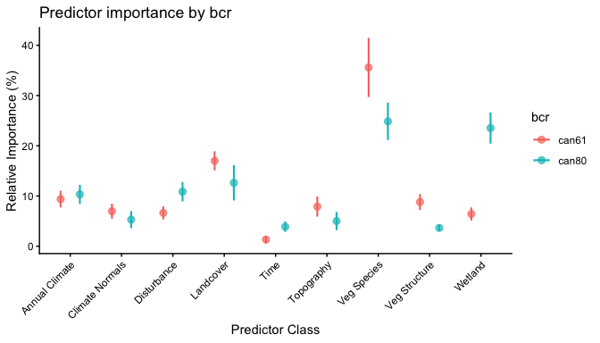

```r
# Create plot of predictor importance grouped by BCR
bam_predictor_importance(species = "OSFL", bcr = bcraoi_v5, group = "bcr", version = "v5", plot=TRUE)
```

We can see that the plot has error bars, indicating standard deviation across bootstraps.

Alternatively, we can just return the raw data to look at the actual values. Let’s try that.

```r
# Create dataframe of predictor importance grouped by BCR
aoi_importance <- bam_predictor_importance(species = "OSFL", bcr = bcraoi_v5,
                                           group = "bcr", version = "v5", plot=FALSE)

# Check results
library(knitr)
kable(aoi_importance, caption="Percent importance of predictor classes, grouped by model subreigon")
```

Percent importance of predictor classes, grouped by model subreigon

| bcr | predictor_class | sum_inf | sd_inf | pooled_sd | sum_all_groups | percent_inf | sd_percent_inf |
| --- | --- | --- | --- | --- | --- | --- | --- |
| can61 | Annual Climate | 9.377087 | 0.3583887 | 1.6593579 | 100 | 9.377087 | 1.6593579 |
| can61 | Climate Normals | 6.967913 | 0.4350609 | 1.4880518 | 100 | 6.967913 | 1.4880518 |
| can61 | Disturbance | 6.635008 | 0.9599027 | 1.3068374 | 100 | 6.635008 | 1.3068374 |
| can61 | Landcover | 16.993761 | 2.9116433 | 1.9006953 | 100 | 16.993761 | 1.9006953 |
| can61 | Time | 1.332594 | NA | 0.7493444 | 100 | 1.332594 | 0.7493444 |
| can61 | Topography | 7.892907 | 3.1363756 | 2.0043338 | 100 | 7.892907 | 2.0043338 |
| can61 | Veg Species | 35.576792 | 1.9793407 | 5.8877411 | 100 | 35.576792 | 5.8877411 |
| can61 | Veg Structure | 8.804426 | 0.6625893 | 1.5825430 | 100 | 8.804426 | 1.5825430 |
| can61 | Wetland | 6.419511 | 1.7723490 | 1.3080375 | 100 | 6.419511 | 1.3080375 |
| can80 | Annual Climate | 10.327121 | 0.4164995 | 1.8995383 | 100 | 10.327121 | 1.8995383 |
| can80 | Climate Normals | 5.296546 | 0.5009308 | 1.7059965 | 100 | 5.296546 | 1.7059965 |
| can80 | Disturbance | 10.858357 | 1.7003463 | 1.9224122 | 100 | 10.858357 | 1.9224122 |
| can80 | Landcover | 12.610881 | 2.7778031 | 3.5050859 | 100 | 12.610881 | 3.5050859 |
| can80 | Time | 3.885610 | NA | 1.0461835 | 100 | 3.885610 | 1.0461835 |
| can80 | Topography | 5.007415 | 2.0544231 | 1.7987681 | 100 | 5.007415 | 1.7987681 |
| can80 | Veg Species | 24.845441 | 1.4323101 | 3.7219325 | 100 | 24.845441 | 3.7219325 |
| can80 | Veg Structure | 3.641568 | 0.2203152 | 0.6663036 | 100 | 3.641568 | 0.6663036 |
| can80 | Wetland | 23.527061 | 8.5098340 | 3.1119115 | 100 | 23.527061 | 3.1119115 |

Right now we’re just looking at one species. What happens if we include multiple species in our `species` argument? We get statistics summarized across species.

Let’s look at all the COSEWIC species.

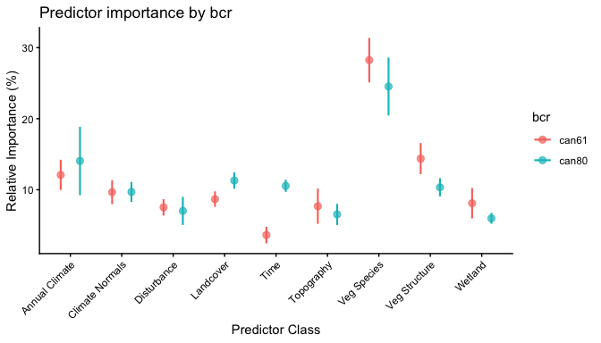

```r
# Create plot of predictor importance grouped by BCR
bam_predictor_importance(species = species_v5, bcr = bcraoi_v5, group = "bcr", version = "v5", plot=TRUE)
```

It looks like biomass is pretty important across species! [MacArthur](https://www.jstor.org/stable/1932254) would be pleased.

There is a metadata table for the model predictors stored in the package. Let’s check out what goes into the biomass class.

```r
library(dplyr)

#Look at the first three rows for a few predictors
predictor_metadata |>
  dplyr::filter(version=="v5", predictor_class=="Veg Structure") |>
  dplyr::select(predictor, definition) |>
  kable(caption = "Model predictors in the 'Veg Structure' class")
```

Model predictors in the ‘Veg Structure’ class

| predictor | definition |
| --- | --- |
| ETHheight_1km | Mean local forest canopy height |
| ETHheight_5x5 | Mean landscape forest canopy height |
| ETHheightcv_1km | Coefficient of variation (CV) of local forest canopy height |
| ETHheightcv_5x5 | Coefficient of variation (CV) of landscape forest canopy height |
| ONRLbiomass_1km | Mean local aboveground living biomass carbon stock density of combined live woody and herbaceous cover |
| ONRLbiomass_5x5 | Mean landscape aboveground living biomass carbon stock density of combined live woody and herbaceous cover |
| LFbiomass_1km | Mean local mass of available canopy fuel per canopy volume unit |
| LFbiomass_5x5 | Mean landscape mass of available canopy fuel per canopy volume unit |
| LFcrownclosure_1km | Mean local percent cover of the tree canopy in a stand |
| LFcrownclosure_5x5 | Mean landscape percent cover of the tree canopy in a stand |
| LFheigth_1km | Mean local height of the top of the vegetated canopy |
| LFheigth_5x5 | Mean landscape height of the top of the vegetated canopy |
| LFheigthcv_1km | Coefficient of variation of local height of the top of the vegetated canopy |
| LFheigthcv_5x5 | Coefficient of variation of landscape height of the top of the vegetated canopy |
| SCANFIclosure_1km | Mean local tree crown closure |
| SCANFIclosure_5x5 | Mean landscape tree crown closure |
| SCANFIheight_1km | Mean local tree height |
| SCANFIheight_5x5 | Mean landscape tree height |
| SCANFIheightcv_1km | Coefficient of variation (CV) of local forest canopy height |
| SCANFIheightcv_5x5 | Coefficient of variation (CV) of landscape forest canopy height |
| RAPTCC_1km | Mean local percent cover estimate of biomass of annual forbs and grasses, perennial forbs and grasses, shrubs, trees |
| RAPTCC_5x5 | Mean landscape percent cover estimate of biomass of annual forbs and grasses, perennial forbs and grasses, shrubs, trees |

Note that not all predictors go into every model! You’ll see there are multiple versions of biomass, which exist because not all spatial predictor products were available for the entire model area. For example, ‘SCANFI_biomass_1km’ was used for all of Canada, while ‘LFbiomass_1km’ was used for Alaska and ‘RAPTCC_1km’ was used for the lower 48 United States.

### 3. Stacked bar chart of predictors

If we want to visualize the predictor importance by individual predictors or with grouping of multiple categories, we can use the `bam_predictor_barchart` function. This function picks two groups for summary, with the group plotted on the x-axis as bins each containing a stacked bar and the second group is shown by fill colours in the stacked bars. The options for grouping are `spp` (species), `bcr` (model subregion), `var` (predictor), or `var_class` (predictor class).

Let’s start by looking at the proportion of influence across predictor categories for each species.

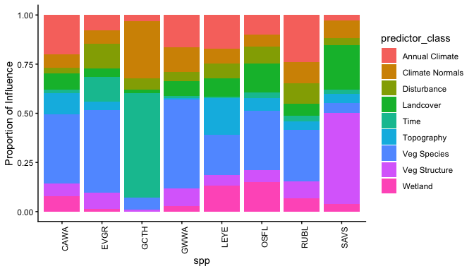

```r
# Create plot of predictor importance for each species grouped by predictor class
bam_predictor_barchart(species = species_v5, bcr = bcraoi_v5,
                       groups=c("spp", "predictor_class"), version = "v5", plot=TRUE)
```

Again, we see that the biomass predictors have the greatest proportion of influence, but that it varies across species. Year has a particularly strong effect for Grey-cheeked Thrush!

Let’s look at the difference between model subregions, or BCRs, in our AOI.

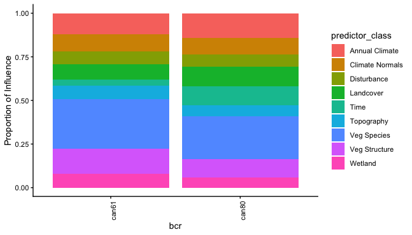

```r
# Create plot of predictor importance for each BCR grouped by predictor class
bam_predictor_barchart(species = species_v5, bcr = bcraoi_v5,
                       groups=c("bcr", "predictor_class"), version = "v5", plot=TRUE)
```

Looks like time and landcover are slightly more important in BCR 80 than BCR 61.

Finally, let’s try looking at the proportion of influence of individual predictors by species.

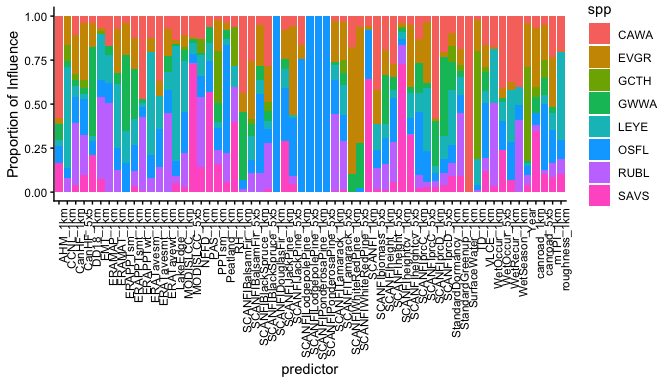

```r
# Create plot of predictor importance for each predictor grouped by species
bam_predictor_barchart(species = species_v5, bcr = bcraoi_v5,
                       groups=c("predictor", "spp"), version = "v5", plot=TRUE)
```

There’s a lot of information here! Note we can see that not every predictor is included in every species model.

Instead of a plot, let’s try extracting the tabular summary for this level of detail.

```r
# Create table of predictor importance for each predictor grouped by species
bam_predictors_v5 <- bam_predictor_barchart(species = species_v5, bcr = bcraoi_v5,
                                            groups=c("predictor", "spp"),
                                            version = "v5", plot=FALSE)

# Check the top 2 per species
bam_predictors_v5 |>
  group_by(spp) |>
  slice_max(order_by = sum_influence, n = 2) |>
  ungroup() |>
  kable(caption = "Summary of model predictor importance by species for AOI")
```

Summary of model predictor importance by species for AOI

| predictor | spp | sum_influence | sum_group1 | prop |
| --- | --- | --- | --- | --- |
| SCANFIprcD_1km | CAWA | 25.55654 | 44.24563 | 0.5776058 |
| ERAPPTwt_1km | CAWA | 22.58115 | 47.67601 | 0.4736375 |
| Year | EVGR | 25.22485 | 99.27414 | 0.2540929 |
| SCANFIprcC_5x5 | EVGR | 14.53146 | 42.32406 | 0.3433380 |
| Year | GCTH | 53.05396 | 99.27414 | 0.5344187 |
| TD_1km | GCTH | 17.96779 | 29.24978 | 0.6142881 |
| SCANFIprcD_5x5 | GWWA | 13.48665 | 29.99566 | 0.4496200 |
| SCANFIprcD_1km | GWWA | 11.33276 | 44.24563 | 0.2561329 |
| roughness_1km | LEYE | 34.28268 | 68.50567 | 0.5004356 |
| LakeEdge_1km | LEYE | 19.26668 | 29.55323 | 0.6519315 |
| Peatland_1km | OSFL | 24.09507 | 39.37290 | 0.6119709 |
| VLCE_1km | OSFL | 11.19864 | 35.29228 | 0.3173112 |
| ERAPPTwt_1km | RUBL | 20.00457 | 47.67601 | 0.4195941 |
| SCANFITamarack_1km | RUBL | 15.27602 | 34.88023 | 0.4379563 |
| SCANFIheightcv_1km | SAVS | 81.97831 | 112.74341 | 0.7271228 |
| MODISLCC_5x5 | SAVS | 27.77705 | 38.12325 | 0.7286118 |